# Data Viz in Practice

David Sasson

3/5/2019

[Hans Rosling](https://en.wikipedia.org/wiki/Hans_Rosling) was the co-founder of the Gapminder Foundation, an organization dedicated to educating the public by using data to dispel common myths about the [so-called developing world](https://www.ted.com/talks/hans_rosling_reveals_new_insights_on_poverty?language=en).

We will create plots that help us better understand trends in world health and economics using the infamous `gapminder` dataset. We will use data to attempt to answer the following two questions:

1. Is it a fair characterization of today’s world to say it is divided into western rich nations and the developing world in Africa, Asia and Latin America?
2. Has income inequality across countries worsened during the last 40 years?

```r
data <- dslabs::gapminder
str(data)
```

```
## 'data.frame':    10545 obs. of  9 variables:
##  $ country         : Factor w/ 185 levels "Albania","Algeria",..: 1 2 3 4 5 6 7 8 9 10 ...
##  $ year            : int  1960 1960 1960 1960 1960 1960 1960 1960 1960 1960 ...
##  $ infant_mortality: num  115.4 148.2 208 NA 59.9 ...
##  $ life_expectancy : num  62.9 47.5 36 63 65.4 ...
##  $ fertility       : num  6.19 7.65 7.32 4.43 3.11 4.55 4.82 3.45 2.7 5.57 ...
##  $ population      : num  1636054 11124892 5270844 54681 20619075 ...
##  $ gdp             : num  NA 1.38e+10 NA NA 1.08e+11 ...
##  $ continent       : Factor w/ 5 levels "Africa","Americas",..: 4 1 1 2 2 3 2 5 4 3 ...
##  $ region          : Factor w/ 22 levels "Australia and New Zealand",..: 19 11 10 2 15 21 2 1 22 21 ...
```

```r
# head(data)
```

### Exploration

1. Sri Lanka or Turkey
2. Poland or South Korea
3. Malaysia or Russia
4. Pakistan or Vietnam
5. Thailand or South Africa

```r
data %>%
  filter(year == 2015 & country %in% c("Sri Lanka","Turkey")) %>%
  select(country, infant_mortality)
```

```
##     country infant_mortality
## 1 Sri Lanka              8.4
## 2    Turkey             11.6
```

| country | infant_mortality | country1 | infant_mortality1 |
| --- | --- | --- | --- |
| Sri Lanka | 8.4 | Turkey | 11.6 |
| Poland | 4.5 | South Korea | 2.9 |
| Malaysia | 6.0 | Russia | 8.2 |
| Pakistan | 65.8 | Vietnam | 17.3 |
| Thailand | 10.5 | South Africa | 33.6 |

We see that the European countries on this list have higher child mortality rates: Poland has a higher rate than South Korea, and Russia has a higher rate than Malaysia. We also see that Pakistan has a much higher rate than Vietnam, and South Africa has a much higher rate than Thailand.

When Hans Rosling gave this quiz to educated groups of people, the average score was less than 2.5 out of 5, worse than what they would have obtained had they guessed randomly.

This comes from a preconceived notion that the world is divided into two groups: the western world (Western Europe and North America), characterized by long life spans and small families, versus the developing world (Africa, Asia, and Latin America) characterized by short life spans and large families.

In order to analyze this world view, our first plot is a scatterplot of life expectancy versus fertility rates (average number of children per woman).

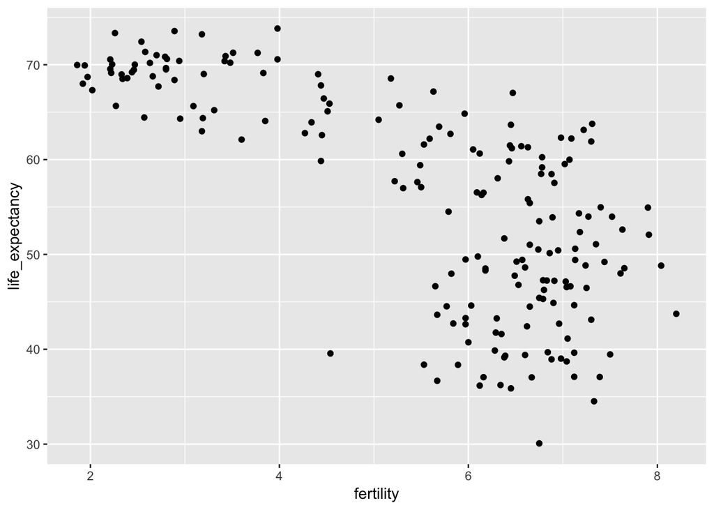

```r
filter(data, year == 1962) %>%
  ggplot(aes(fertility, life_expectancy)) +
  geom_point()
```

Most points fall into two distinct categories:

1. Life expectancy around 70 years and 3 or less children per family. Life expectancy lower then 65 years and more than 5 children per family.
2. To confirm that indeed these countries are from the regions we expect, we can use color to represent continent.

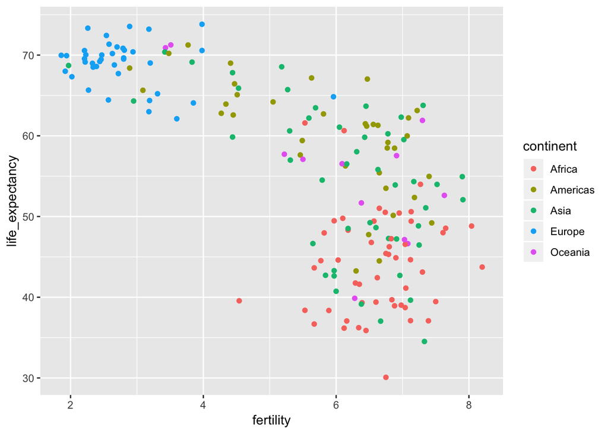

```r
filter(data, year == 1962) %>%
  ggplot( aes(fertility, life_expectancy, color = continent)) +
  geom_point()
```

In 1962, “the West versus developing world” view was grounded in some reality. Is this still the case 50 years later?

In order to compare to 2012, we can utilize faceting. This approach stratifies the data by some variable and makes the same plot for each strata

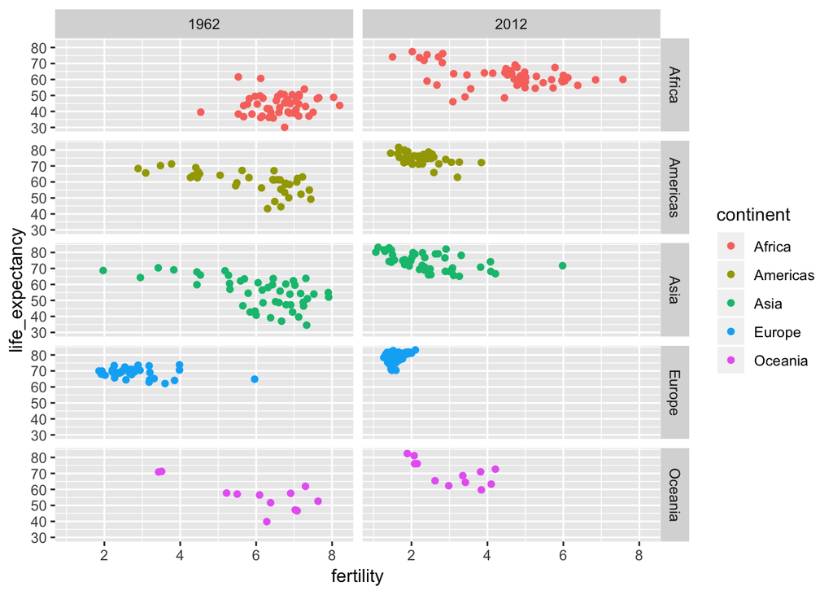

```r
filter(data, year%in%c(1962, 2012)) %>%
  ggplot(aes(fertility, life_expectancy, col = continent)) +
  geom_point() +
  facet_grid(continent~year)
```

But we want to compare 1962 and 2012 only. In this case, there is just one variable and we use . to let facet know that we are not using one of the variables

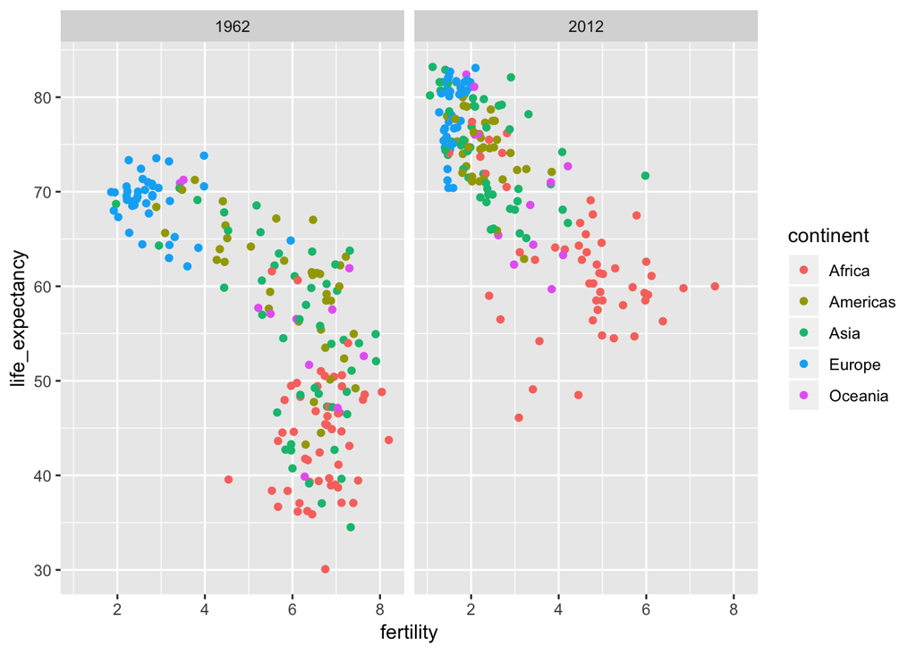

```r
filter(data, year%in%c(1962, 2012)) %>%
  ggplot(aes(fertility, life_expectancy, col = continent)) +
  geom_point() +
  facet_grid(. ~ year)
```

This plot clearly shows that the majority of countries have moved from the developing world cluster to the western world one

To explore how this transformation happened through the years, we can make the plot for several years.

The function facet_wrap permits us to do this by automatically wrapping the series of plots so that each display has viewable dimensions

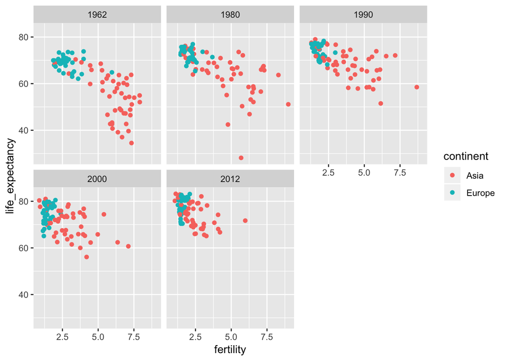

```r
years <- c(1962, 1980, 1990, 2000, 2012)
continents <- c("Europe", "Asia")
data %>%
  filter(year %in% years & continent %in% continents) %>%
  ggplot( aes(fertility, life_expectancy, col = continent)) +
  geom_point() +
  facet_wrap(~year)
```

This plot shows how most Asian countries have improved at a much faster rate than European ones.

## Time Series

Once we see these plots, new questions emerge. For example, which countries are improving more and which ones less? Was the improvement constant during the last 50 years or was it more accelerated during certain periods? For a closer look that may help answer these questions, we introduce time series plots. Time series plots have time in the x-axis and an outcome or measurement of interest on the y-axis.

For example, here is a trend plot of United States fertility rates

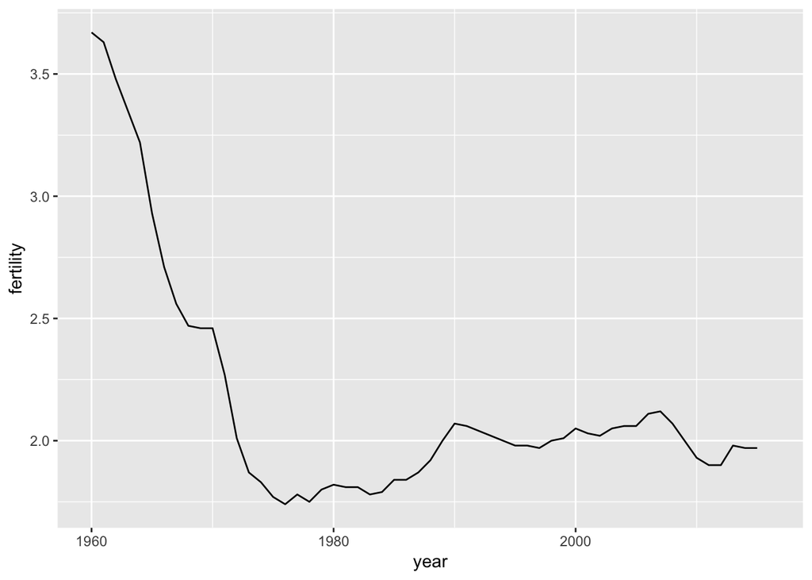

```r
data %>%
  filter(country == "United States") %>%
  ggplot(aes(year, fertility)) +
  geom_line()
```

We see that the trend is not linear at all. Instead there is sharp drop during the 60s and 70s to below 2. Then the trend comes back to 2 and stabilizes during the 90s.

Let’s try to create the same plot for two countries.

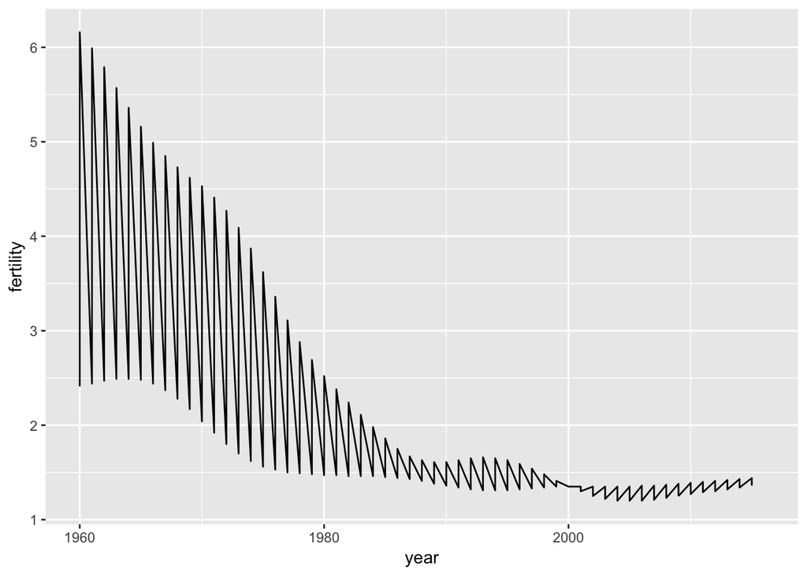

```r
countries <- c("South Korea","Germany")

data %>% filter(country %in% countries) %>%
  ggplot(aes(year,fertility)) +
  geom_line()
```

This is **not** the plot that we want. Rather than a line for each country, the points for both countries are joined.

To let `ggplot` know that there are two curves that need to be made separately, we assign each point to a `group`, one for each country:

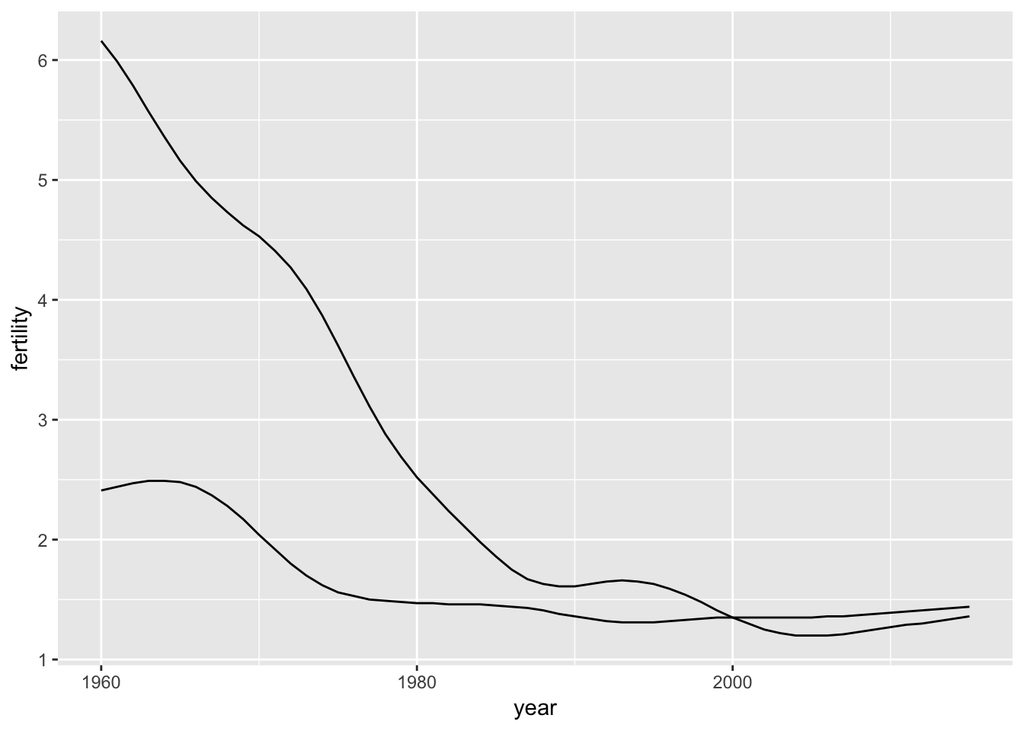

```r
countries <- c("South Korea","Germany")

data %>%
  filter(country %in% countries & !is.na(fertility)) %>%
  ggplot(aes(year, fertility, group = country)) +
  geom_line()
```

But which line goes with which country? We can assign colors to make this distinction.

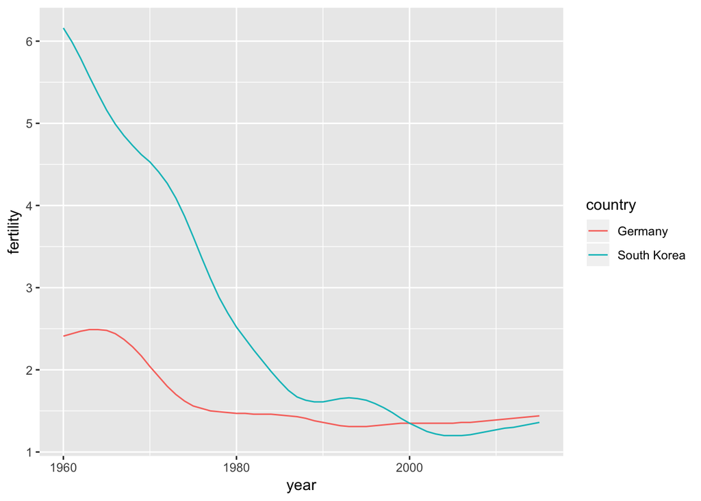

```r
countries <- c("South Korea","Germany")

data %>%
  filter(country %in% countries & !is.na(fertility)) %>%
  ggplot(aes(year,fertility, col = country)) +
  geom_line()
```

The plot clearly shows how South Korea’s fertility rate dropped drastically during the 60s and 70s, and by 1990 had a similar rate to that of Germany.

## Income

We now shift our attention to the second question related to the commonly held notion that wealth distribution across the world has become worse during the last decades. When general audiences are asked if poor countries have become poorer and rich countries become richer, the majority answers yes.

Let’s start by quickly examining the data by region.

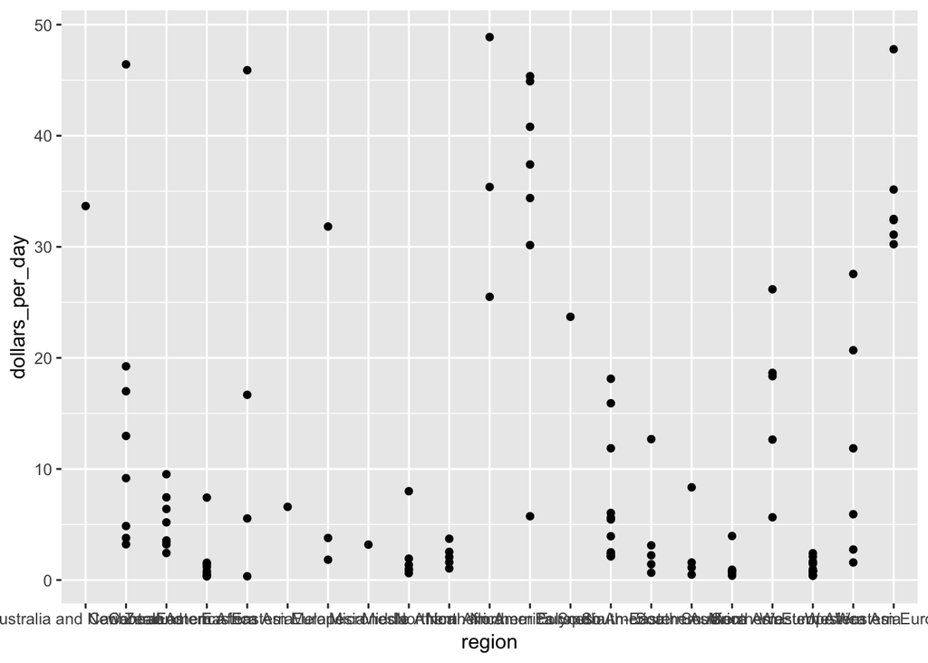

```r
data <- data %>%  mutate(dollars_per_day = gdp/population/365)

past_year <- 1970

p <- data %>%
  filter(year == past_year & !is.na(gdp)) %>%
  ggplot(aes(region, dollars_per_day))

p + geom_point()
```

The default ggplot2 behavior is to write the labels horizontally and here we run out of room. We can easily fix this by either rotating the axes or rotating the labels.

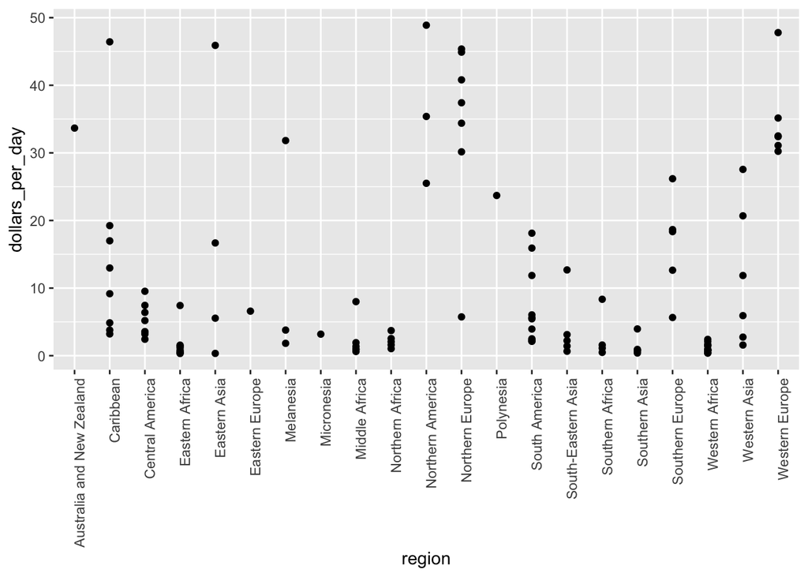

```r
p + geom_point() +
  theme(axis.text.x = element_text(angle = 90, hjust = 1))
```

Data exploration is often made easier if we order the strata by some interpretable quantity (instead of regions). This can be achieved using the `reorder` function

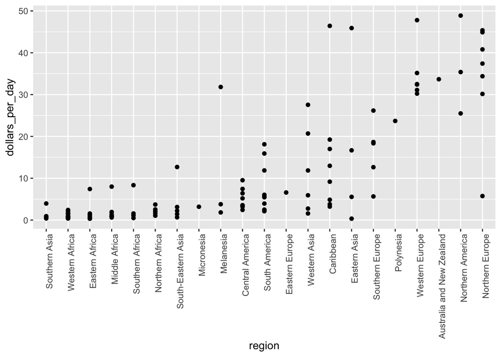

```r
p <- data %>%
  filter(year == past_year & !is.na(gdp)) %>%
  mutate(region = reorder(region, dollars_per_day, FUN = median)) %>%
  ggplot(aes(region, dollars_per_day)) +
  geom_point() +
  theme(axis.text.x = element_text(angle = 90, hjust = 1))
p
```

We can already see that there is indeed a “west versus the rest” dichotomy: we see two clear groups, with the rich group composed of North America, Northern and Western Europe, New Zealand and Australia.

In cases in which we are concerned that the boxplot summary is too simplistic, we can show stacked smooth densities or histograms.

```r
data <- data %>%
  mutate(group = case_when(
    region %in% c("Western Europe", "Northern Europe","Southern Europe",
                    "Northern America", "Australia and New Zealand") ~ "West",
    region %in% c("Eastern Asia", "South-Eastern Asia") ~ "East Asia",
    region %in% c("Caribbean", "Central America", "South America") ~ "Latin America",
    continent == "Africa" & region != "Northern Africa" ~ "Sub-Saharan Africa",
    TRUE ~ "Others"))
```

We turn this `group` variable into a factor to control the order of the levels:

```r
data <- data %>%
  mutate(group = factor(group,
                        levels = c("Others", "Latin America", "East Asia", "Sub-Saharan Africa", "West")))
```

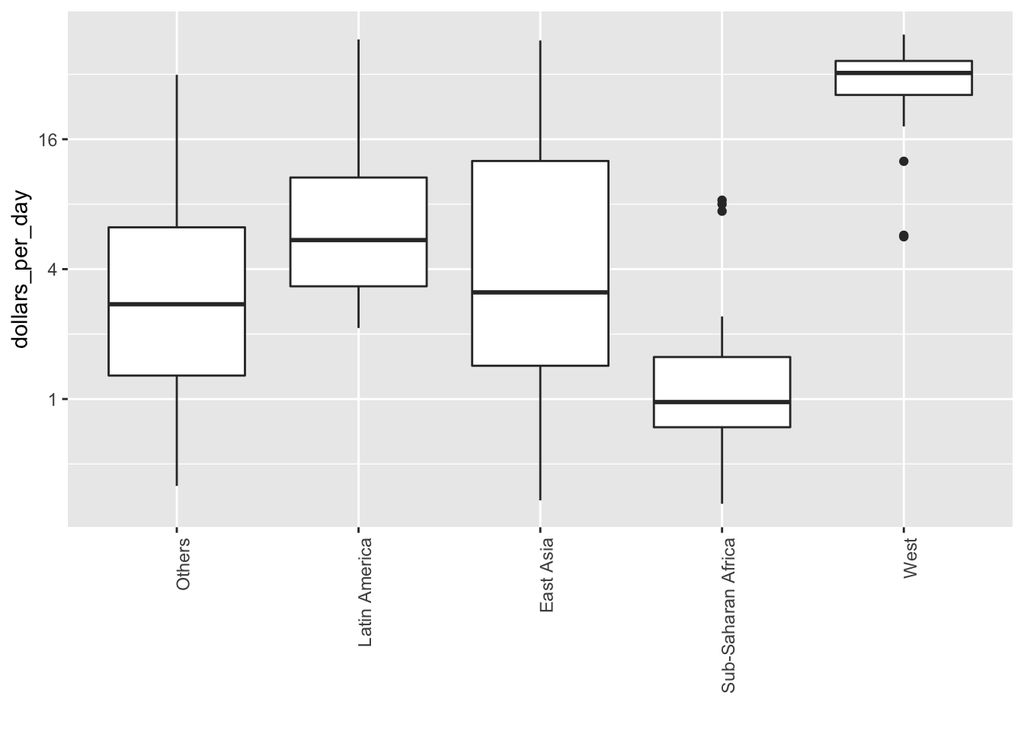

```r
p <- data %>%
  filter(year == past_year & !is.na(gdp)) %>%
  ggplot(aes(group, dollars_per_day)) +
  geom_boxplot() +
  theme(axis.text.x = element_text(angle = 90, hjust = 1)) +
  scale_y_continuous(trans = "log2") +
  xlab("")
p
```

Boxplots will not permit us to discover bimodal distributions!

```r
library(ggridges)
```

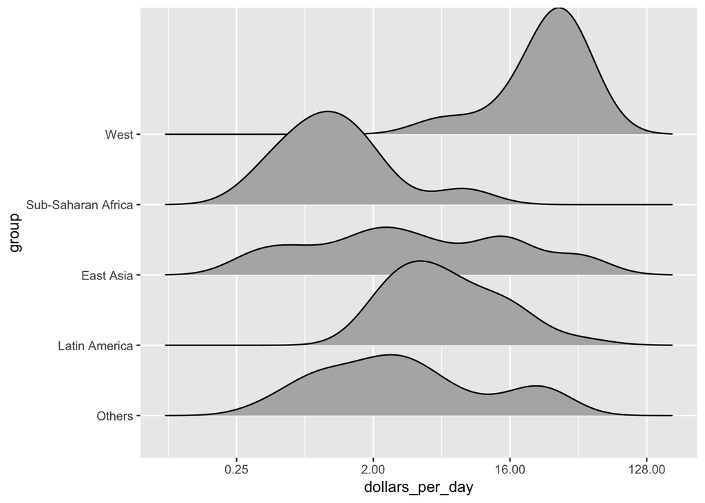

```r
p <- data %>%
  filter(year == past_year & !is.na(dollars_per_day)) %>%
  ggplot(aes(dollars_per_day, group)) +
  scale_x_continuous(trans = "log2")

p  + geom_density_ridges()
```

Data exploration clearly showed that in 1970 there was a “west versus the rest” dichotomy. But does this dichotomy persist?

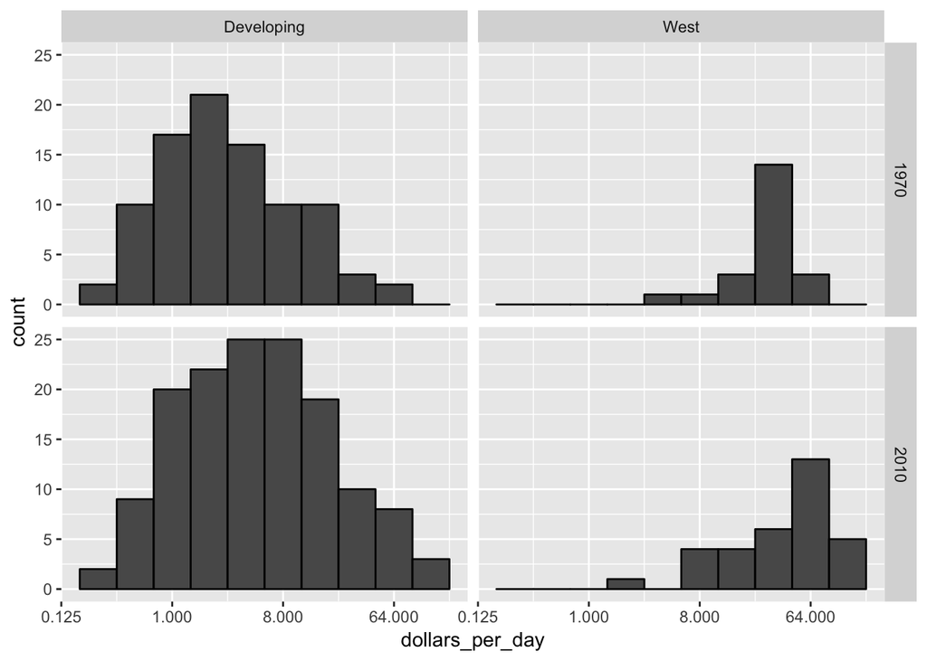

```r
past_year <- 1970
present_year <- 2010

data %>%
  filter(year %in% c(past_year, present_year) & !is.na(gdp)) %>%
  mutate(west = ifelse(group == "West", "West", "Developing")) %>%
  ggplot(aes(dollars_per_day)) +
  geom_histogram(binwidth = 1, color = "black") +
  scale_x_continuous(trans = "log2") +
  facet_grid(year ~ west)
```

Before we interpret the findings of this plot, we notice that there are more countries represented in the 2010 histograms than in 1970: the total counts are larger. Several countries were founded after 1970

```r
country_list_1 <- data %>%
  filter(year == past_year & !is.na(dollars_per_day)) %>%
  pull(country)

country_list_2 <- data %>%
  filter(year == present_year & !is.na(dollars_per_day)) %>%
  pull(country)

country_list <- intersect(country_list_1, country_list_2)
```

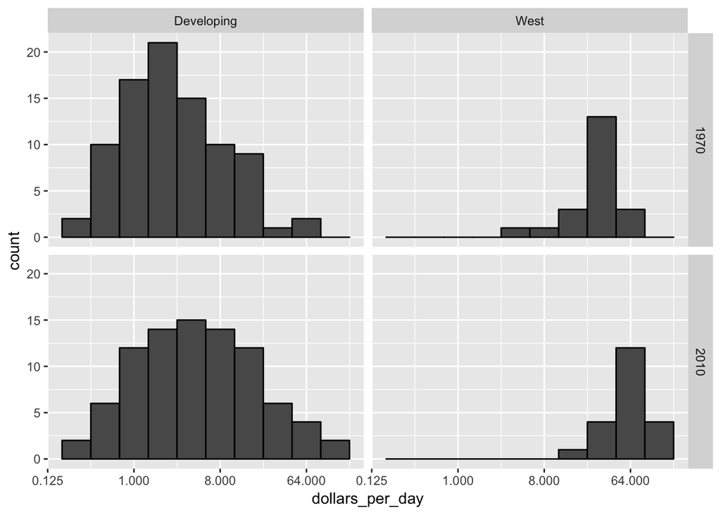

```r
data %>%
  filter(year %in% c(past_year, present_year) & country %in% country_list) %>%
  mutate(west = ifelse(group == "West", "West", "Developing")) %>%
  ggplot(aes(dollars_per_day)) +
  geom_histogram(binwidth = 1, color = "black") +
  scale_x_continuous(trans = "log2") +
  facet_grid(year ~ west)
```

We now see that while the rich countries have become a bit richer, but percentage-wise, the poor countries appear to have improved more.

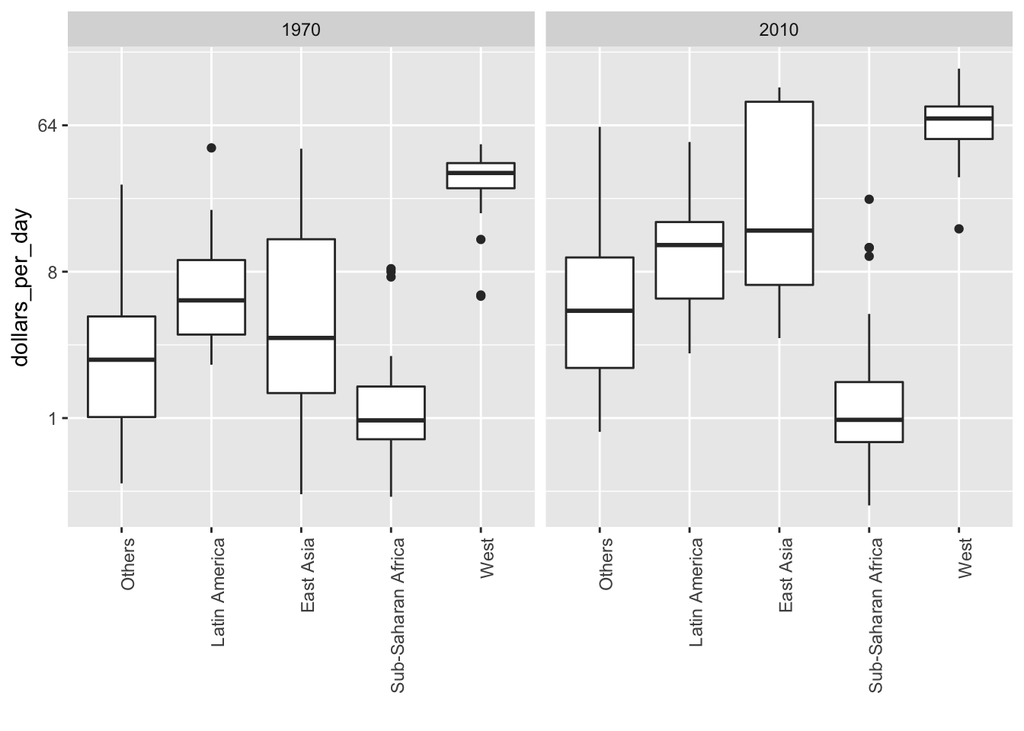

```r
data %>%
  filter(year %in% c(past_year, present_year) & country %in% country_list) %>%
  ggplot(aes(group, dollars_per_day)) +
  geom_boxplot() +
  theme(axis.text.x = element_text(angle = 90, hjust = 1)) +
  scale_y_continuous(trans = "log2") +
  xlab("") +
  facet_grid(. ~ year)
```

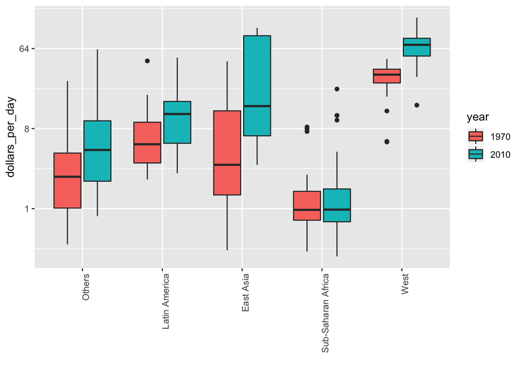

```r
data %>%
  filter(year %in% c(past_year, present_year) & country %in% country_list) %>%
  mutate(year = factor(year)) %>%
  ggplot(aes(group, dollars_per_day, fill = year)) +
  geom_boxplot() +
  theme(axis.text.x = element_text(angle = 90, hjust = 1)) +
  scale_y_continuous(trans = "log2") +
  xlab("")
```

The income gap between rich and poor countries has narrowed considerably during the last 40 years.

[Here’s](https://goo.gl/DdGLLf) a clever and informative summary of the Gapminder dataset using the R package `gganimate`

Finally, [here](https://ourworldindata.org/) is a great resource which gives an overview of many health data related issues via data visualization.

# Exercises

### Part I

#### 1

Make a basic scatterplot of GDP per capita and life expectancy

#### 2

Change the graph from a scatterplot to a line using a smoother

#### 3

Now change the x axis to a log scale

#### 4

Using only data from 1950, plot GDP per capita and life expectancy in a scatterplot. Color points according to continent and scale the x axis with a log 10 transform.

Challenge:

Try out the size and shape aesthetics in a scatterplot of lifeExp vs gdpPercap.

- Make the points’ size correspond to the population.
- Make the points’ shape correspond to the continent
- What happens if you use aes(color=pop)?

#### 5

Create a histogram of life expectancy for 2007

#### 6

Compare the distributions for the different continents using density estimates

#### 7

Express the same information in a boxplot

#### 8

Using only data from 2007, plot GDP per capita and life expectancy for each continent using faceting. Scale the x axes by log10

- How could you facet horizontally?
- Try using `facet_wrap` for each continent
- Now `facet_wrap` by year, coloring each continent differently
- How could you facet by year and country?